# Exercises 1.1-1.8

Aleksandra Kilijańska

2023-04-17

## 1.1 (Normal percentiles).

The qnorm function returns the percentiles (quantiles) of a normal distribution. Use the qnorm function to find the 95th percentile of the standard normal distribution. Then, use the qnorm function to find the quartiles of the standard normal distribution (the quartiles are the 25th, 50th, and 75th percentiles). Hint: Use c(.25, .5, .75) as the first argument to qnorm.

```r
qnorm(.95)
```

```
## [1] 1.644854
```

```r
qnorm(c(.25,.5,.75))
```

```
## [1] -0.6744898  0.0000000  0.6744898
```

## 1.2 (Chi-square density curve).

Use the curve function to display the graph of the χ2(1) density. The chi-square density function is dchisq.

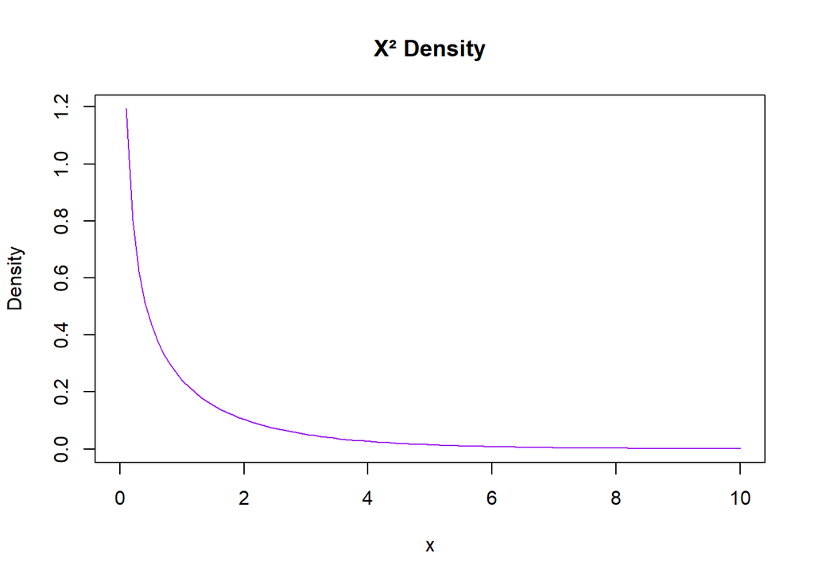

```r
curve(dchisq(x, df = 1), from=0, to=10, n=100, main = "X² Density", xlab="x", ylab = "Density", col = "purple")
```

## 1.3 (Gamma densities).

Use the curve function to display the graph of the gamma density with shape parameter 1 and rate parameter 1. Then use the curve function with add=TRUE to display the graphs of the gamma density with shape parameter k and rate 1 for 2,3, all in the same graphics window. The gamma density function is dgamma. Consult the help file ?dgamma to see how to specify the parameters.

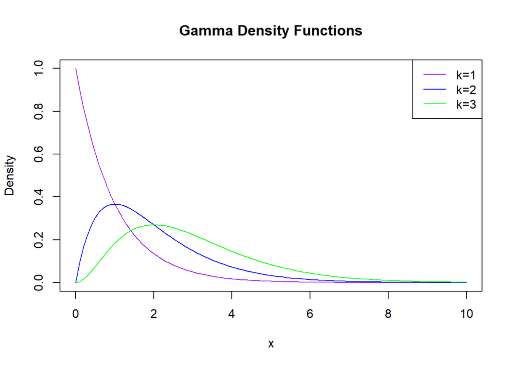

```r
curve(dgamma(x, shape = 1, rate = 1), from = 0, to = 10, col = "purple",
      xlab = "x", ylab = "Density", main = "Gamma Density Functions")
curve(dgamma(x, shape = 2, rate = 1), from = 0, to = 10, add = TRUE, col = "blue")
curve(dgamma(x, shape = 3, rate = 1), from = 0, to = 10, add = TRUE, col = "green")
legend("topright", legend=c("k=1", "k=2", "k=3"), col=c("purple", "blue", "green"), lty=1)
```

## 1.4. (Binomial probabilities).

Let X be the number of “ones” obtained in 12 rolls of a fair die. Then X has a Binomial(n = 12, p = 1/3) distribution. Compute a table of binomial probabilities for x = 0,1,…,12 by two methods: a. Use the probability density formula and vectorized arithmetic in R. Use 0:12 for the sequence of x values and the choose function to compute the binomial coefficients (n k).

```r
k = 0:12
n = 12
p = 1/3
a = choose(n,k)*p^k*(1-p)^(n-k)
print(a)
```

```
##  [1] 7.707347e-03 4.624408e-02 1.271712e-01 2.119520e-01 2.384460e-01
##  [6] 1.907568e-01 1.112748e-01 4.768921e-02 1.490288e-02 3.311751e-03
## [11] 4.967626e-04 4.516023e-05 1.881676e-06
```

2. Use the dbinom function provided in R and compare your results using both methods.

```r
b = dbinom(k,n,p)
print(b)
```

```
##  [1] 7.707347e-03 4.624408e-02 1.271712e-01 2.119520e-01 2.384460e-01
##  [6] 1.907568e-01 1.112748e-01 4.768921e-02 1.490288e-02 3.311751e-03
## [11] 4.967626e-04 4.516023e-05 1.881676e-06
```

```r
table=cbind(k,a,b)
print(table)
```

```
##        k            a            b
##  [1,]  0 7.707347e-03 7.707347e-03
##  [2,]  1 4.624408e-02 4.624408e-02
##  [3,]  2 1.271712e-01 1.271712e-01
##  [4,]  3 2.119520e-01 2.119520e-01
##  [5,]  4 2.384460e-01 2.384460e-01
##  [6,]  5 1.907568e-01 1.907568e-01
##  [7,]  6 1.112748e-01 1.112748e-01
##  [8,]  7 4.768921e-02 4.768921e-02
##  [9,]  8 1.490288e-02 1.490288e-02
## [10,]  9 3.311751e-03 3.311751e-03
## [11,] 10 4.967626e-04 4.967626e-04
## [12,] 11 4.516023e-05 4.516023e-05
## [13,] 12 1.881676e-06 1.881676e-06
```

## 1.5. (Binomial CDF).

Let X be the number of “ones” obtained in 12 rolls of a fair die. Then X has a Binomial(n = 12, p = 1/3) distribution. Compute a table of cumulative binomial probabilities (the CDF) for x = 0,1,…,12 by two methods: (1) using cumsum and the result of Exercise 1.4, and (2) using the pbinom function.

```r
binominal_cdf_a=cumsum(a)
binominal_cdf_b=pbinom(k,n,p)
table_binomal_cdf=cbind(k, binominal_cdf_a,binominal_cdf_b)
table_binomal_cdf
```

```
##        k binominal_cdf_a binominal_cdf_b
##  [1,]  0     0.007707347     0.007707347
##  [2,]  1     0.053951426     0.053951426
##  [3,]  2     0.181122646     0.181122646
##  [4,]  3     0.393074678     0.393074678
##  [5,]  4     0.631520714     0.631520714
##  [6,]  5     0.822277544     0.822277544
##  [7,]  6     0.933552360     0.933552360
##  [8,]  7     0.981241568     0.981241568
##  [9,]  8     0.996144445     0.996144445
## [10,]  9     0.999456196     0.999456196
## [11,] 10     0.999952958     0.999952958
## [12,] 11     0.999998118     0.999998118
## [13,] 12     1.000000000     1.000000000
```

What is P(X > 7)?

```r
1-pbinom(7,n,p)
```

```
## [1] 0.01875843
```

## 1.6 (Presidents’ heights).

Refer to Example 1.2 where the heights of the United States Presidents are compared with their main opponent in the presidential election. Create a scatterplot of the loser’s height vs the winner’s height using the plot function. Compare the plot to the more detailed plot shown in the Wikipedia article “Heights of Presidents of the United States and presidential candidates” [54].

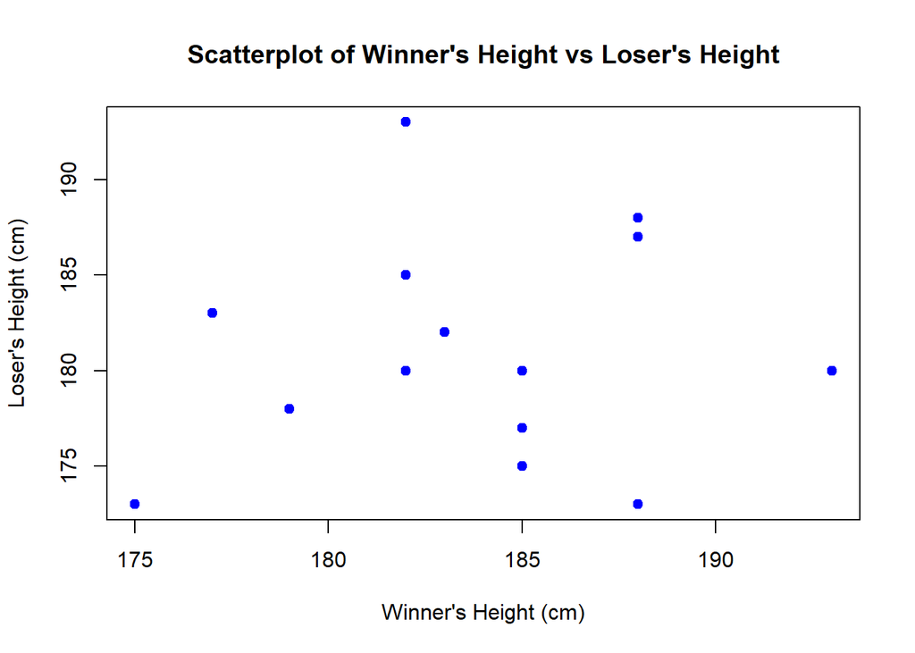

```r
winner = c(185, 182, 182, 188, 188, 188, 185, 185, 177, 182, 182, 193, 183, 179, 179, 175)
opponent = c(175, 193, 185, 187, 188, 173, 180, 177, 183, 185, 180, 180, 182, 178, 178, 173)

plot(winner, opponent, xlab = "Winner's Height (cm)",
      ylab = "Loser's Height (cm)",
      main = "Scatterplot of Winner's Height vs Loser's Height", col="blue",pch=19)
```

## 1.7 (Simulated “horsekicks” data).

The rpois function generates random observations from a Poisson distribution. In Example 1.3, we compared the deaths due to horsekicks to a Poisson distribution with mean λ = 0.61, and in Example 1.4 we simulated random Poisson(λ = 0.61) data. Use the rpois function to simulate very large (n = 1000 and n = 10000) Poisson(λ = 0.61) random samples. Find the frequency distribution, mean and variance for the sample. Compare the theoretical Poisson density with the sample proportions (see Example 1.4).

```r
samples1 = rpois(1000, 0.61)
samples2= rpois(10000,0.61)

freq1 = table(samples1)
mean1 = mean(samples1)
var1 = var(samples1)

freq2 = table(samples2)
mean2 = mean(samples2)
var2 = var(samples2)


cat("Sample of size 1000:\n")
```

```
## Sample of size 1000:
```

```r
cat("Frequency distribution:\n", freq1, "\n")
```

```
## Frequency distribution:
##  557 312 104 25 2
```

```r
cat("Mean:", mean1, "\n")
```

```
## Mean: 0.603
```

```r
cat("Variance:", var1, "\n")
```

```
## Variance: 0.622013
```

```r
cat("Sample of size 10000:\n")
```

```
## Sample of size 10000:
```

```r
cat("Frequency distribution:\n", freq2, "\n")
```

```
## Frequency distribution:
##  5471 3313 999 188 23 6
```

```r
cat("Mean:", mean2, "\n")
```

```
## Mean: 0.5997
```

```r
cat("Variance:", var2, "\n")
```

```
## Variance: 0.5923191
```

```r
theoretical = dpois(0:4, lambda=.61)
sample = freq1 / 1000
cbind(theoretical, sample)
```

```
##   theoretical sample
## 0 0.543350869  0.557
## 1 0.331444030  0.312
## 2 0.101090429  0.104
## 3 0.020555054  0.025
## 4 0.003134646  0.002
```

## 1.8 (horsekicks, continued).

Refer to Example 1.3. Using the ppois function, compute the cumulative distribution function (CDF) for the Poisson distribution with mean λ = 0.61, for the values 0 to 4. Compare these probabilities with the empirical CDF. The empirical CDF is the cumulative sum of the sample proportions p, which is easily computed using the cumsum function. Combine the values of 0:4, the CDF, and the empirical CDF in a matrix to display these results in a single table.

```r
cdf_Poisson = ppois(0:4, 0.61)
empirical_cdf1 = cumsum(freq1 / 1000)
matrix(c(0:4,cdf_Poisson, empirical_cdf1),ncol=3)
```

```
##      [,1]      [,2]  [,3]
## [1,]    0 0.5433509 0.557
## [2,]    1 0.8747949 0.869
## [3,]    2 0.9758853 0.973
## [4,]    3 0.9964404 0.998
## [5,]    4 0.9995750 1.000
```